# Mini-Assignment 3

Uijeong “UJ” Hwang

2026-10-01

Mini assignments are designed to give you an opportunity to practice and better understand the class material through hands-on activities. **Do not share your work with other students – not your RPubs username, not a document URL, not the HTML file – as this could lead to academic dishonesty.**

# Instructions

## Healthcare Equity Analysis

In this assignment, you will examine the spatial distribution of hospitals in Metro Atlanta and explore how it relates to various socioeconomic factors. The goal is to better understand potential inequities in healthcare access across neighborhoods and sociodemographic groups. The definition of Metro Atlanta varies – in this assignment, we use the following 11 counties: Cherokee, Clayton, Cobb, DeKalb, Douglas, Fayette, Forsyth, Fulton, Gwinnett, Henry, and Rockdale.

You will use hospital POI data (provided via [this link](https://raw.githubusercontent.com/ujhwang/urban-analytics-2026/main/Assignment/mini_3/hospital_11counties.geojson)) along with Census ACS data. Select relevant variables from the ACS, conduct exploratory data analysis with these two datasets, and share your findings. Be sure to address the guiding question: *Is the spatial distribution of hospitals in Metro Atlanta equitable?*

### Equity vs. Equality

- **Equity** recognizes that each group of people has different circumstances/demands and allocates resources/opportunities accordingly.
- **Equality** means each group of people is given the same resources or opportunities.

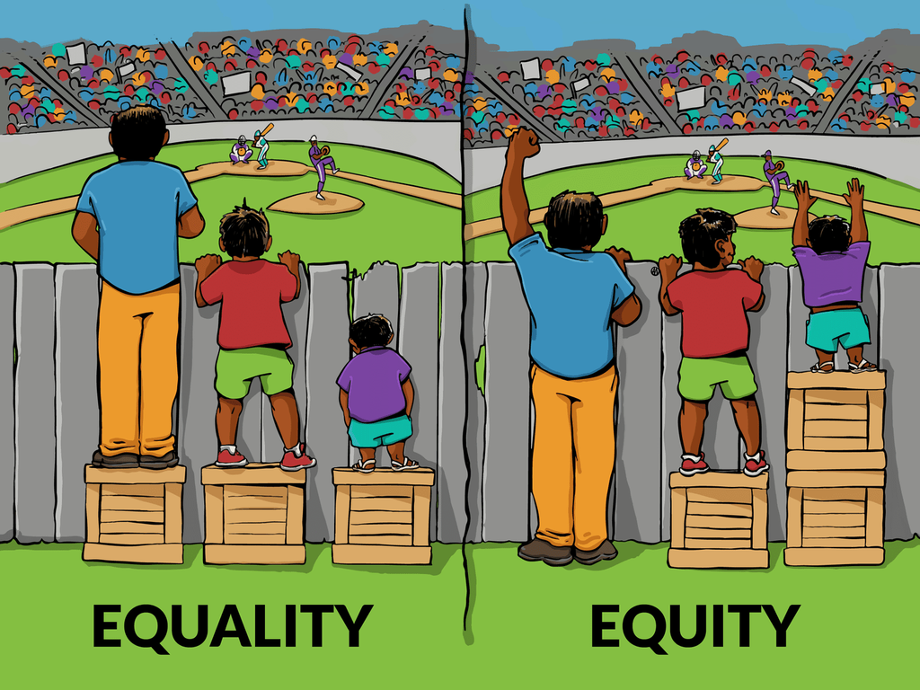

### Directions

1. Import the hospital POI data ([link](https://raw.githubusercontent.com/ujhwang/urban-analytics-2026/main/Assignment/mini_3/hospital_11counties.geojson)) and make sure it is tidy and ready for analysis.
2. Explore variables in the Census ACS 5-year estimates, carefully select those that are relevant for an equity analysis, and **provide justification for each variable you select**.
   - Think about how each variable captures *different circumstances and needs for healthcare*.
3. Download ACS data for the selected variables at the Census Tract level for the 11 counties using the `tidycensus`.
4. Prepare the data for analysis:
   - Check for missing values and handle them appropriately.
   - Create new variables if needed (e.g., proportions, densities).
   - Join the POI data with the ACS data.
   - Ensure coordinate reference systems (CRS) are appropriate for distance calculations.
5. Define and compute your operational measure of healthcare access (the dependent variable).
   - Identify suitable metric(s) and **justify your choices**. Example metrics include:
     - The number of hospitals within *X* miles.
     - The presence of a hospital within *X* miles.
     - The distance to the nearest hospital.
     - The average distance to the *X* nearest hospitals.
   - Compute your chosen measure(s).
6. Analyze the spatial distribution of hospitals from an equity perspective:
   - Conduct exploratory data analysis and present **at least two graphs** and **at least two maps**.
   - Fit appropriate regression model(s) to test associations between healthcare access and socioeconomic factors.
   - Conclude with your verdict: *“Is the spatial distribution of hospitals in Metro Atlanta equitable?”*

# Working with R Markdown

- You may copy and paste the instructions above into your script.
- Keep your document readable, well-formatted, and concise:
  - Avoid making the document unnecessarily lengthy by printing or plotting everything.
  - **ADD COMMENTS before and/or inside each code chunk** (using `#`) to explain what your code is doing.
- Remember that every time you click **Knit**, the entire script runs.

# Submission Guidelines

- Write your report and R code in an R Markdown (`.Rmd`) script.
- Use the **Knit** button in RStudio to render the document as HTML.
- Submit **one of the following two** through Canvas. They are graded identically – pick whichever you prefer.
  - **Option A – RPubs link.** Publish the rendered HTML to **RPubs** and submit the URL.
  - **Option B – HTML file.** Submit the rendered `.html` file itself. Choose this if you would rather not publish your work publicly.
- Due **10/9/2026 Friday 11:59 PM**.
- A short quiz on this assignment may follow in the session after it is due. If there is one, the quiz score acts as a multiplier on this assignment’s grade. See [Assignment quizzes](https://ujhwang.github.io/urban-analytics-2026/#assignment-quizzes) in the syllabus.